# Hiper Parametrización 2 - La venganza

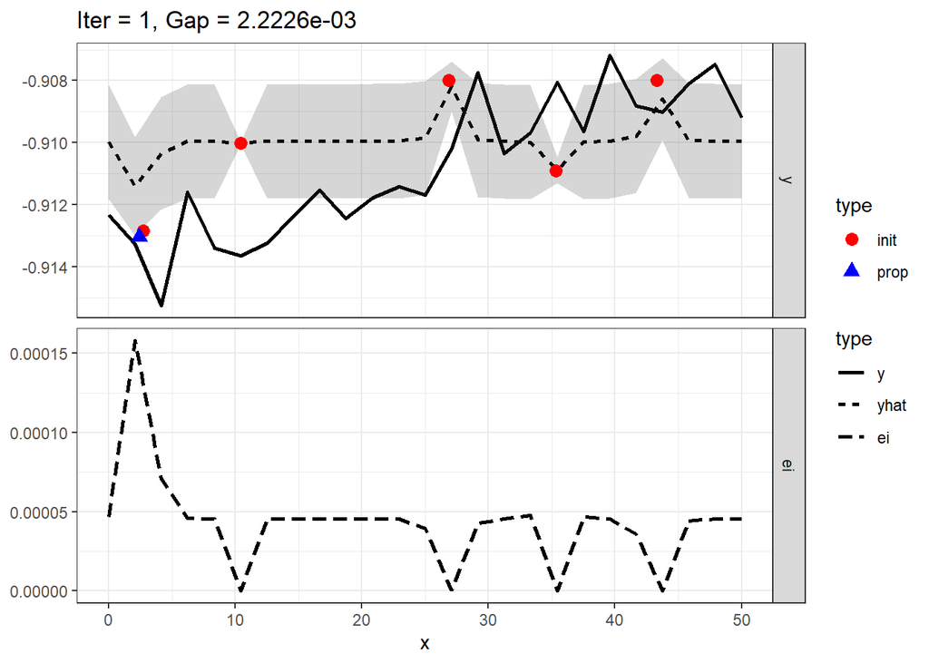

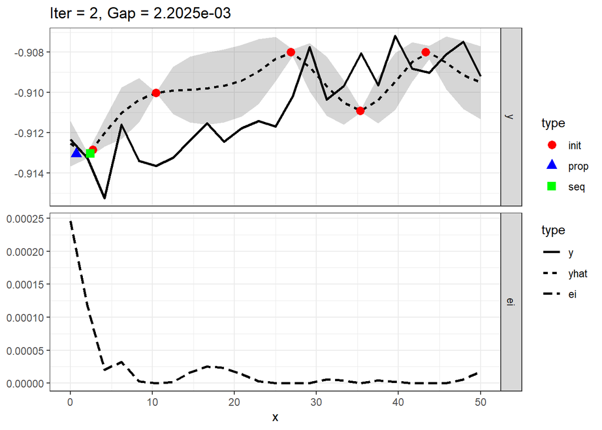

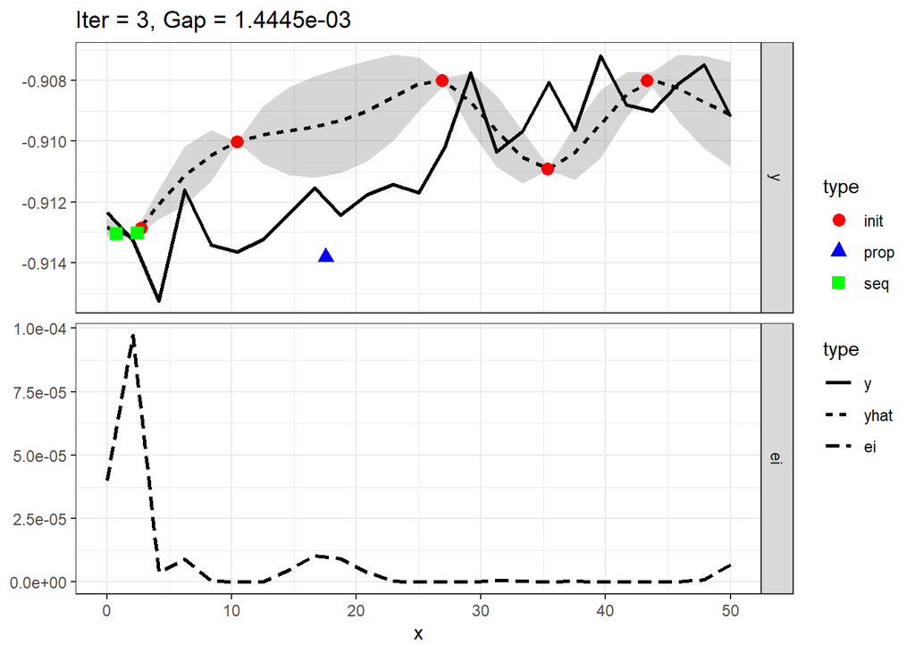

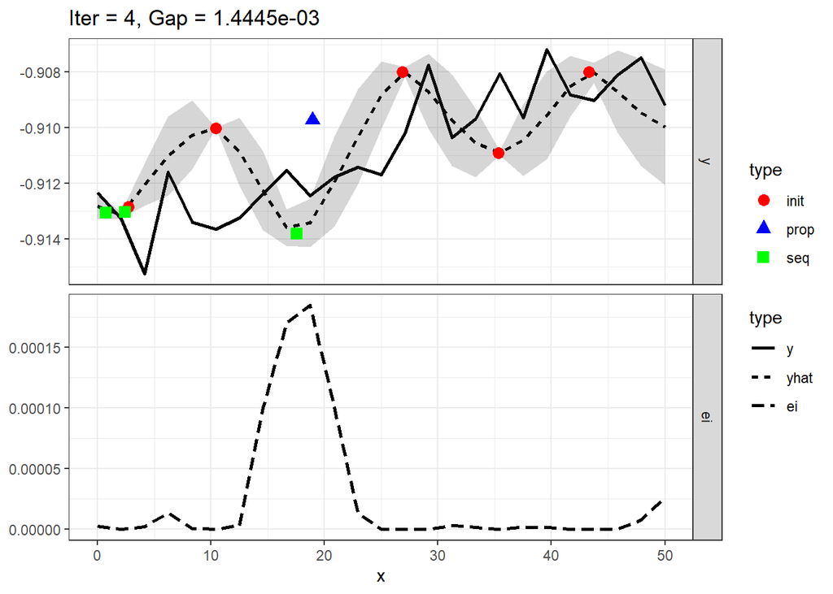

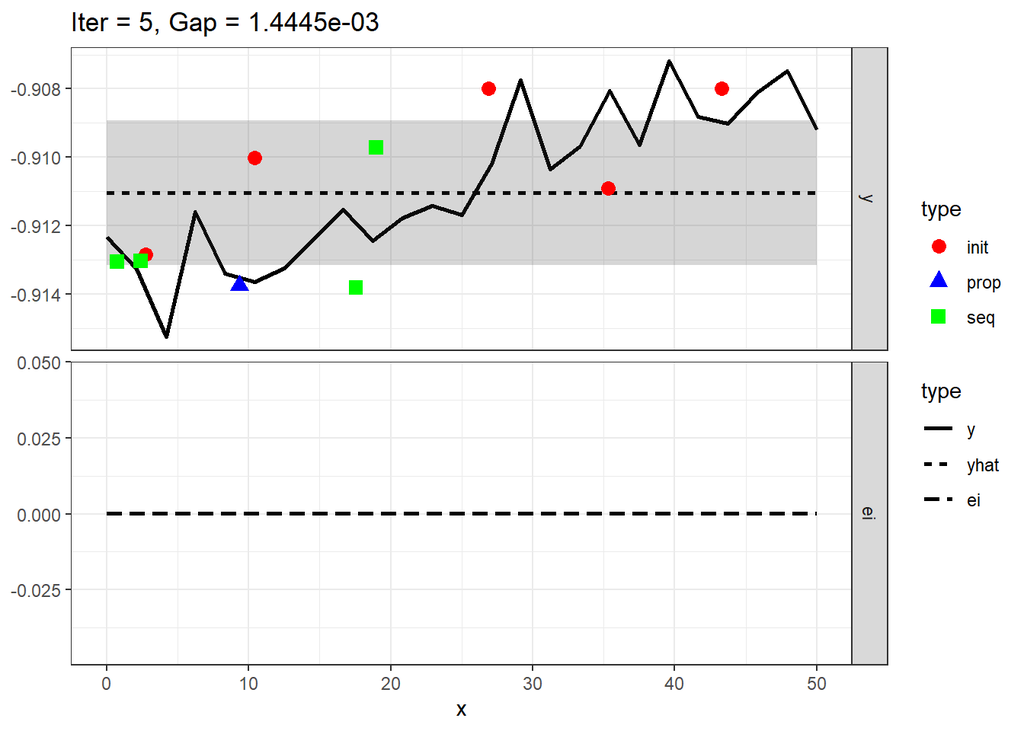

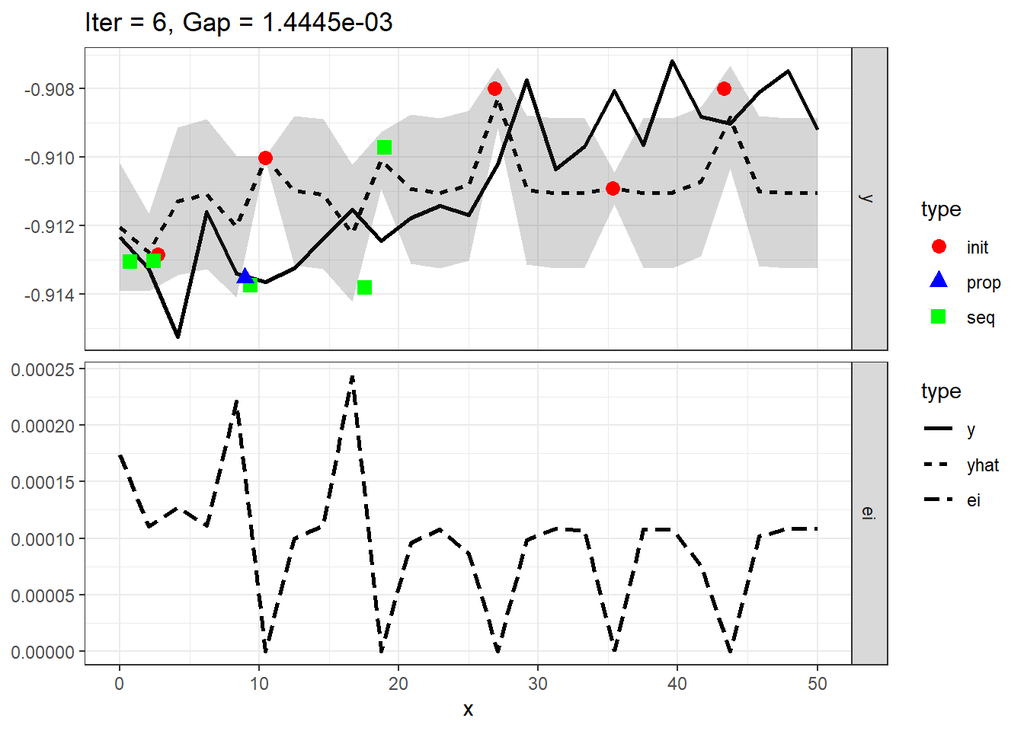

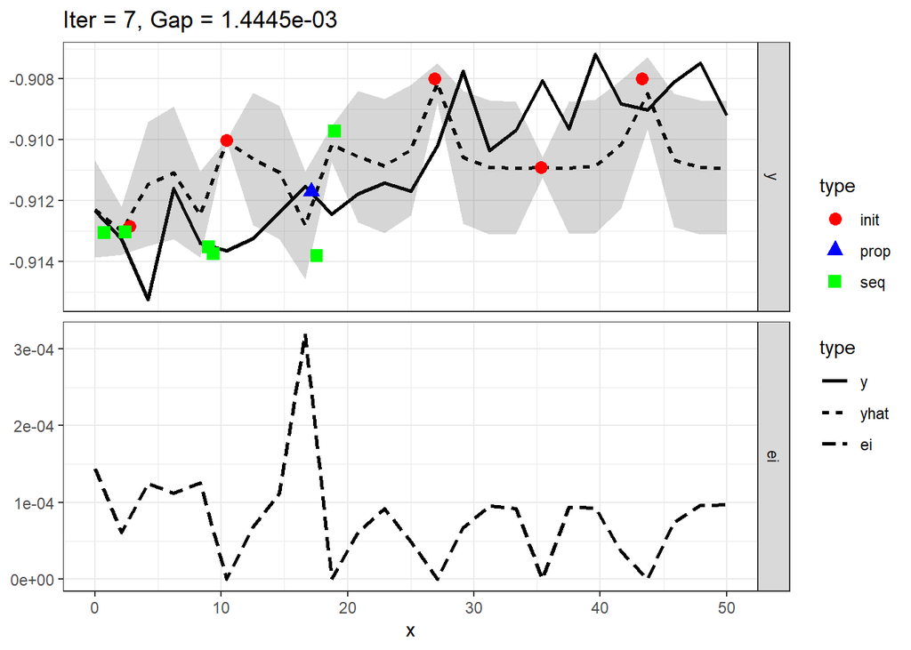

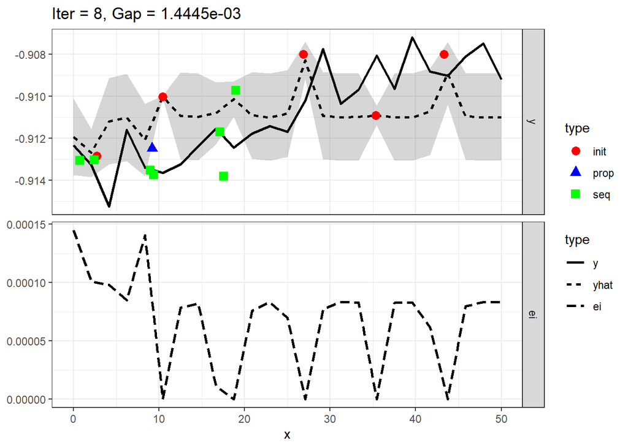

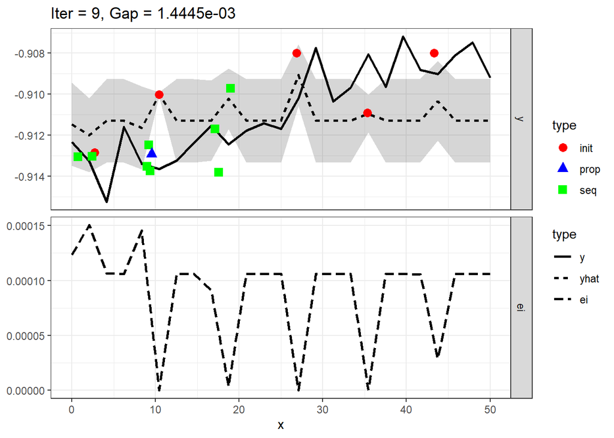

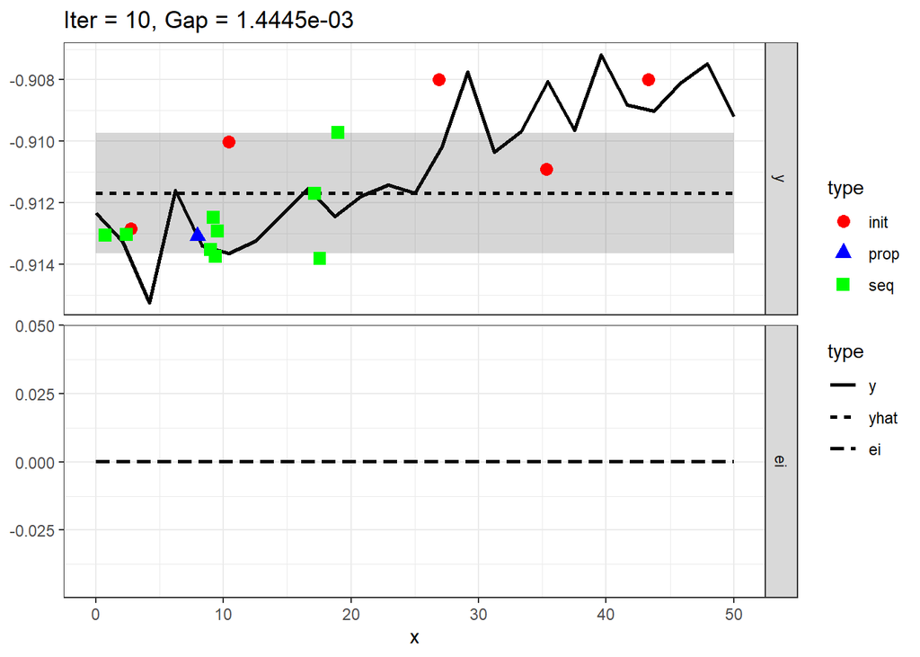

```r
run <- readRDS("resultados/11_res4.RDS")
plotExampleRun(run, densregion = TRUE, gg.objects = list(theme_bw()), pause=FALSE)
```

```r
print(run)
```

```
## MBOExampleRun
## Number of parameters        : 1
## Parameter names             : x
## Parameter types             : numericvector
## Global Opt (estimated)      : -9.1525e-01
## Gap for best point          : NA
## True points per dim.        : 25
## Objectives                    : 1
## Points proposed per iter      : 1
##
## Infill criterion            : Expected improvement (ei)
##   Direction of optimization : maximize
##   Requirement               : SE estimation
##   Components                : se, mean
##   Parameters                : se.threshold=1e-06
## Infill optimizer              : focussearch
## Infill optimizer restarts     : 1
## Final point by                : best.true.y
## Learner                     : regr.km
## Learner settings:
## jitter=FALSE,covtype=matern3_2
## Recommended parameters:
## x=17.6
## Objective: y = -9.138e-01
```

Pero como bien sabemos, los optimos unidimensionales, no necesariamente son los optimos en todas sus dimensiones. Busquemos el optimo de las dos variables conjuntas:

```r
objetivo <- function(x) {
  - modelar_lgbm(
      abril2018$datos[abril2018$muestra],
      abril2018$clases[abril2018$muestra],
      param = list(lambda_l2 = x$l2, learning_rate = x$lr)
    )$best_score
}

set.seed(vsemillas[1])

obj.fun = makeSingleObjectiveFunction(
  name = "2 parametros",
  fn = objetivo,
  par.set = makeParamSet(
    makeNumericParam("lr",  lower = 0.01, upper = 0.5),
    makeNumericParam("l2",  lower = 0.0  , upper =   30.0)
  ),
  has.simple.signature = FALSE,
  global.opt.value = -1
)

ctrl = makeMBOControl(propose.points = 1)
ctrl = setMBOControlTermination(ctrl, iters = 50L)
ctrl = setMBOControlInfill(
  ctrl,
  crit = makeMBOInfillCritEI(),
  opt = "focussearch",
  opt.focussearch.points = 50L
)

lrn = makeMBOLearner(ctrl, obj.fun)
design = generateDesign(20L, getParamSet(obj.fun), fun = lhs::maximinLHS)

surr.km <-
  makeLearner("regr.km", predict.type = "se", covtype = "matern3_2")

run  <-  mbo(obj.fun, design = design, learner = surr.km, control = ctrl)


saveRDS(run, "resultados/11_res5.RDS")
```

```r
run <- readRDS("resultados/11_res5.RDS")
print(run)
```

```
## Recommended parameters:
## lr=0.346; l2=23.3
## Objective: y = -0.919
##
## Optimization path
## 20 + 50 entries in total, displaying last 10 (or less):
##            lr        l2          y dob eol error.message exec.time
## 61 0.16537933 17.629283 -0.9168110  41  NA          <NA>      2.48
## 62 0.25263833 19.247919 -0.9160781  42  NA          <NA>      2.61
## 63 0.16419648 13.857144 -0.9145780  43  NA          <NA>      2.51
## 64 0.47511387 26.121810 -0.9105838  44  NA          <NA>      2.67
## 65 0.06000789 28.775192 -0.9036419  45  NA          <NA>      2.03
## 66 0.15749779  3.144298 -0.9166016  46  NA          <NA>      2.75
## 67 0.18166235 18.717174 -0.9158996  47  NA          <NA>      2.79
## 68 0.34603015 23.258367 -0.9185419  48  NA          <NA>      2.77
```

[output cut: 24 more lines]

Tomemos todas las iteraciones para visualizarlas:

```r
iter <- as.data.frame(run$opt.path)
iter
```

| lr | l2 | y | dob | eol | error.message | exec.time | ei | error.model | train.time | prop.type | propose.time | se | mean |
| --- | --- | --- | --- | --- | --- | --- | --- | --- | --- | --- | --- | --- | --- |
| 0.10346147 | 9.05265918 | -0.9161790 | 0 | NA | NA | 2.55 | NA | NA | NA | initdesign | NA | NA | NA |
| 0.46224309 | 19.13768632 | -0.9113481 | 0 | NA | NA | 2.84 | NA | NA | NA | initdesign | NA | NA | NA |
| 0.19514442 | 4.11543160 | -0.9164803 | 0 | NA | NA | 2.89 | NA | NA | NA | initdesign | NA | NA | NA |
| 0.03855196 | 24.24839955 | -0.9001360 | 0 | NA | NA | 2.10 | NA | NA | NA | initdesign | NA | NA | NA |
| 0.14581551 | 16.41629227 | -0.9162867 | 0 | NA | NA | 3.17 | NA | NA | NA | initdesign | NA | NA | NA |
| 0.37172718 | 16.86208745 | -0.9121164 | 0 | NA | NA | 3.20 | NA | NA | NA | initdesign | NA | NA | NA |
| 0.21031324 | 21.91968543 | -0.9144374 | 0 | NA | NA | 3.30 | NA | NA | NA | initdesign | NA | NA | NA |
| 0.32384866 | 8.17953246 | -0.9114909 | 0 | NA | NA | 4.15 | NA | NA | NA | initdesign | NA | NA | NA |
| 0.38752748 | 10.85652509 | -0.9107129 | 0 | NA | NA | 4.32 | NA | NA | NA | initdesign | NA | NA | NA |
| 0.24000546 | 27.95073985 | -0.9153672 | 0 | NA | NA | 3.11 | NA | NA | NA | initdesign | NA | NA | NA |

[output cut: 60 more lines]

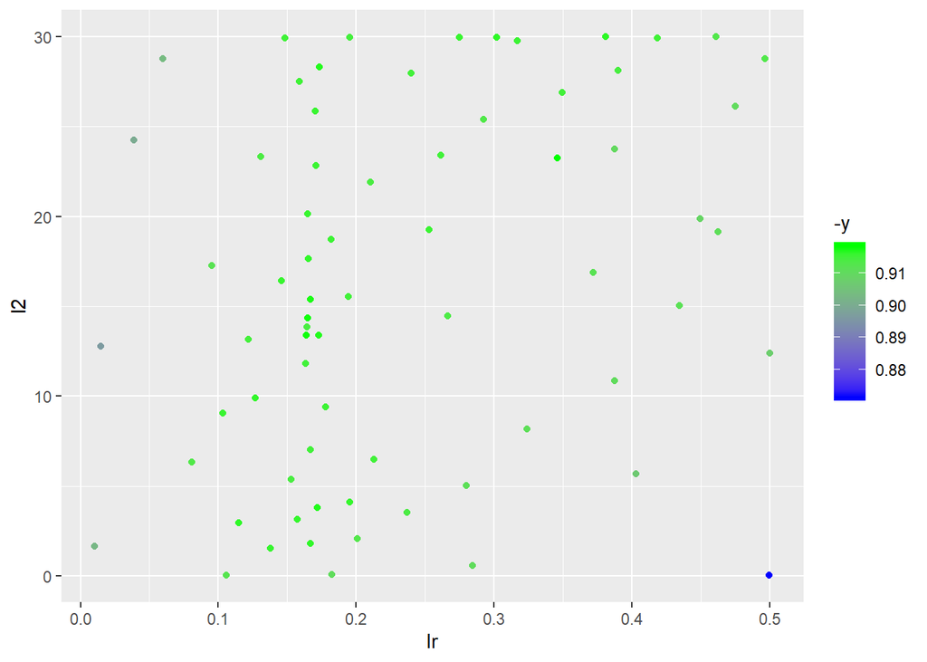

```r
ggplot(iter, aes(x=lr,y=l2,color=-y)) +
    scale_color_gradient(low = "blue", high = "green") +
    geom_point()
```

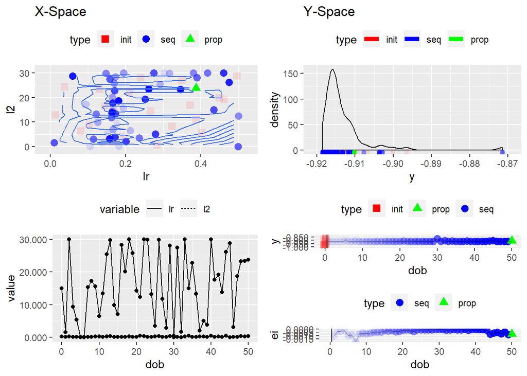

```r
plot(run)
```

¿Observaciones? Los escucho!

¡OJO! Estamos trabajando con muy pocas iteraciones en LGBM, el learning rate es muy sencible a ese valor.

Pasamos ahora a buscar el mejor juego de parámetros, pero para la función que nos interesa, que es la ganancia. Buscaremos los parámetros en `febrero2018`, validando contra `abril2018` y luego tomaremos 2 caminos.

- Ejecutaremos esos modelos para `junio2018`
- Reentrenaremos en `abril2018` y testearemos en `junio2018`

```r
febrero2018 <- cargar_meses(201802, 0)
junio2018 <- cargar_meses(201806, 0)
```

No usaremos para este caso `CV`.

```r
modelar_lgbm_train <- function(ds, target, param = list()) {

  ds_lgm <- lgb.Dataset(data.matrix(ds), label = target)
  p <- c(param, list(objective = "binary"))

  modelo <- lgb.train(params=p,
                ds_lgm,
                25,
                verbose = -1)
  modelo
}
```

Por un tema de comodidad y ahorro de tiempos, vamos en la función objetivo realizar más pasos de los que la misma debería, entrenando en más de un mes y almacenando valores en una variables `global`:

```r
resultados2 <- data.table()

objetivo2 <- function(x) {

  m1 <- modelar_lgbm_train(febrero2018$datos, febrero2018$clases,
                           param = list(lambda_l2 = x$l2, learning_rate = x$lr) )
  m2 <- modelar_lgbm_train(abril2018$datos,abril2018$clases,
                           param = list(lambda_l2 = x$l2, learning_rate = x$lr) )
  p1 <- predict(m1, data.matrix(abril2018$datos),  type = "prob")
  p2 <- predict(m1, data.matrix(junio2018$datos),  type = "prob")
  p3 <- predict(m2, data.matrix(junio2018$datos),  type = "prob")

  g1 <- data.table(p=p1, c=abril2018$clases)
  gan_m1_abril <- g1[p > 0.025, sum(ifelse(c == 1, 19500,-500))]

  g2 <- data.table(p=p2, c=junio2018$clases)
  gan_m1_junio <- g2[p > 0.025, sum(ifelse(c == 1, 19500,-500))]

  g3 <- data.table(p=p3, c=junio2018$clases)
  gan_m2_junio <- g3[p > 0.025, sum(ifelse(c == 1, 19500,-500))]

  resultados2 <<- rbindlist(list(resultados2, data.table(lr = x$lr,
                                         l2 = x$l2,
                                         gan_m1_abril = gan_m1_abril,
                                         gan_m1_junio = gan_m1_junio,
                                         gan_m2_junio = gan_m2_junio )))

  - gan_m1_abril
}

objetivo2(list(l2=5, lr=0.3))
```

```
## [1] -9330000
```

```r
objetivo2(list(l2=20, lr=0.1))
```

```
## [1] -9436000
```

```r
resultados2
```

| lr | l2 | gan_m1_abril | gan_m1_junio | gan_m2_junio |
| --- | --- | --- | --- | --- |
| 0.3 | 5 | 9330000 | 9922500 | 10522000 |
| 0.1 | 20 | 9436000 | 10159000 | 11268500 |

Y ahora buscamos los “mejores” parámetros:

```r
resultados2 <- data.table()

set.seed(vsemillas[1])

obj.fun = makeSingleObjectiveFunction(
  name = "Experimento 1",
  fn = objetivo2,
  par.set = makeParamSet(
    makeNumericParam("lr",  lower = 0.01, upper = 0.5),
    makeNumericParam("l2",  lower = 0.0  , upper =   30.0)
  ),
  has.simple.signature = FALSE,
  global.opt.value = -1
)

ctrl = makeMBOControl(propose.points = 1)
ctrl = setMBOControlTermination(ctrl, iters = 50L)
ctrl = setMBOControlInfill(
  ctrl,
  crit = makeMBOInfillCritEI(),
  opt = "focussearch",
  opt.focussearch.points = 50L
)

lrn = makeMBOLearner(ctrl, obj.fun)
design = generateDesign(20L, getParamSet(obj.fun), fun = lhs::maximinLHS)

surr.km <-
  makeLearner("regr.km", predict.type = "se", covtype = "matern3_2")

run  <-  mbo(obj.fun, design = design, learner = surr.km, control = ctrl)


saveRDS(run, "resultados/11_res6.RDS")
fwrite(resultados2, "resultados/11_res7.csv")
```

```r
run <- readRDS("resultados/11_res6.RDS")

resultados2 <- fread("resultados/11_res7.csv")
```

```r
print(run)
```

```
## Recommended parameters:
## lr=0.0805; l2=6.34
## Objective: y = -10087000.000
##
## Optimization path
## 20 + 50 entries in total, displaying last 10 (or less):
##           lr        l2         y dob eol error.message exec.time
## 61 0.1913571 20.210913 -10009500  41  NA          <NA>     10.21
## 62 0.2120453 24.362801  -9875000  42  NA          <NA>      9.81
## 63 0.1566292 27.694461  -9815500  43  NA          <NA>      9.69
## 64 0.2608656  9.819749  -9633000  44  NA          <NA>     10.72
## 65 0.3430356 19.184489  -9449500  45  NA          <NA>     12.73
## 66 0.3699244 28.277940  -9438000  46  NA          <NA>      9.77
## 67 0.4527747 14.379365  -9377500  47  NA          <NA>     10.33
## 68 0.1944262 18.916978  -9833500  48  NA          <NA>      9.45
```

[output cut: 24 more lines]

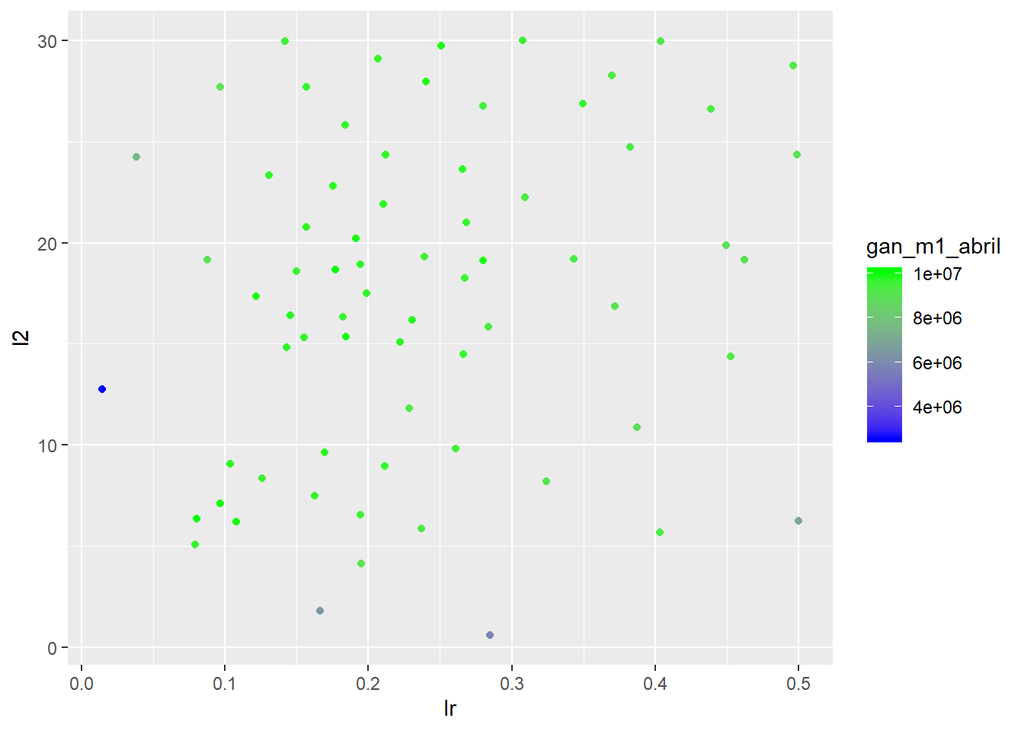

```r
ggplot(resultados2, aes(x=lr,y=l2,color=gan_m1_abril)) +
    scale_color_gradient(low = "blue", high = "green") +
    geom_point()
```

Agregamos algunas columnas auxiliares que nos ayuden en nuestro análisis:

```r
# Elementos aleatorios
resultados2$design <- 0
resultados2$design[1:20] <- 1

#Rankings
resultados2$r_gan_m1_abril <- frank(-resultados2$gan_m1_abril)
resultados2$r_gan_m1_junio <- frank(-resultados2$gan_m1_junio)
resultados2$r_gan_m2_junio <- frank(-resultados2$gan_m2_junio)

setcolorder(resultados2, c("design", "lr","l2","gan_m1_abril","r_gan_m1_abril","gan_m1_junio" ,"r_gan_m1_junio","gan_m2_junio","r_gan_m2_junio") )
```

Y guardamos en un archivos de Excel:

```r
library(openxlsx)

write.xlsx(resultados2, "resultados/11_res7.xlsx")
```

```
## Note: zip::zip() is deprecated, please use zip::zipr() instead
```

Continuemos en Excel… y si, todos pecamos alguna vez! Exploremos `resultados/11_res7.xlsx`